# Regression Analysis of Used Cars from Craiglist

Eszter Diamant

2021 01 03

## Introduction:

The aim of this analysis to determine linear regression among price of used cars and their odometer reading and age. The main research question is how these descriptive variables affect the price of the vehicles while the main focus will be the causality behind the association of the variables. The first assumption is that the higher the odometer reading and older the car is, the worth of the vehicle will decrease. The selected dataset is originated from craiglist, a well-know website for selling and buying for everyone, focusing on the United state market.

## Data:

To begin with, the data is collected from craiglist, an American multinational e-commerce website where anybody can buy or sell anything in 570 cities from 70 countries. However, the data set only contains data on cars for sale in the United States. During the data exploration, it was found that the data set not only have used cars but also new ones realized on the market in 2020. It is a well-known practice for salons to sell those cars that were tried out by customers several times but for the analysis, there are considered as new cars. But, only the 2020 cars were removed as new ones but it might be that there are still this type of vehicles from the recent years. This can be considered as a measurement error, due to the fact that even if they are listed as used cars, they do not have a high values in odometer.

|  | min | max | mean | median | sd | skew | number_obs |
| --- | --- | --- | --- | --- | --- | --- | --- |
| Odometer | 1 | 2043755555 | 106379.69 | 92000 | 3392464.39 | 599.23 | 364905 |
| Price | 1 | 3615215112 | 27078.61 | 12888 | 5992908.04 | 601.64 | 364905 |
| Age | 1 | 120 | 9.06 | 7 | 7.77 | 3.38 | 364905 |

As you can see in the above summary statistics, there are some extreme values that also can be stated as a real classical measurement errors ecause it is more likely an error in the data collection process. For this reason, where the odometer reading did not exceed 70000 miles but was over 1000000miles (that is still a huge number) were dropped from the dataset. By this, it might be stated that these try-out cars were removed from the analysis. On the other hand, hose cars that had lower price than 500 dollars and more than 60000 dollars were also dropped due to the assumption that they are wreckage or a new car. In this regard, they can be called as extreme values that are not needed for the analysis. In the end, as another example for potential measurement error is the value assessment of the used cars by the advertisers. People tend to overestimate the value of the used vehicles and ask for higher price that they really worth. This may influence the outcome and punctuality of the regression model and its coefficients later on.

After the cleaning the summary statistics change in the following way:

|  | min | max | mean | median | sd | skew | number_obs |
| --- | --- | --- | --- | --- | --- | --- | --- |
| Odometer | 70000 | 1000000 | 135389.28 | 125178 | 56565.45 | 4.36 | 223469 |
| Price | 500 | 60000 | 11417.46 | 8600 | 9216.36 | 1.75 | 223469 |
| Age | 1 | 120 | 10.99 | 10 | 6.51 | 2.71 | 223469 |

## Regression Analysis:

### 1) Exploration:

When I have started the analysis, I only wanted to compare the prices of cars to their odometer reading. But, as you can see from the appendix figures from 1 to 2, there is a huge spread in the explanatory and dependent variables. Therefore, before the real regression analysis, the omitted variables must be noted: only including the odometer readings as the main explanatory variable might result in serious errors in the outcome. People not only check the odometer reading but also the quality, the age, the model, etc. of the car. So, beside the simple linear regression, a multiple regression that focuses on the odometer readings and the age of cars was also required for carrying out the analysis properly. Although, the problem of omitted variables still exists such as the quality of the vehicles, or the models. On the other, as you can see in the same charts, a pattern tends to appear in the change of prices: after a certain amount of time, the price starts to raise after a stable decreasing pattern. It can be explained that after a time, cars became so called retro and if they are still working, their worth will increase. By this, the regression models are also investigating this phenomenon.

### 2) Log Transformation:

After exploration of the variables, the log price and level age and odometer reading are suggested to use. Even if the interpretations of the models are more complex, for carrying out a multiply regression, the dependent variable need to be the same. The log price seemed to be working better for both cases at the same time. In details, log transformation helps to decrease the high variety in the variables. Usually, the high skeweness is a sign for need for log transformation, although, the odometer had the highest while the price the lowest. As a result, the price will be ß multiplied by 100% higher or lower (depending on the regression) by one unit increase in x variable.

### 3) Regression Models:

Based on the above stated assumption, eight models were created mostly for comparing purposes. Firstly, the simple linear regressions were made on both price-odometer and price-age. After that, each regression was made piecewise linear spline, 250.000 miles for odometer reading, 25 for age. Also, for checking for polynomials, they were investigated as quadratic regression. And, as the focus the analysis, a multiple regression is made where the explanatory variables are the age and odometer reading. in the end, a weighted regression was also carried out.

Log(Price) - Odometer Reading:

ln(price) = $\alpha$ + ß * odometer

ln(price) = $\alpha$ + ß$_{1}$ * odometer(odometer < 250000) + ß$_{2}$ * odometer(odometer <= 250000)

ln(price) = $\alpha$ + ß$_{1}$ * odometer + ß$_{2}$ * odometer$^{2}$

Log(Price) - Age:

ln(price) = $\alpha$ + ß * age

ln(price) = $\alpha$ + ß$_{1}$ * age(age < 25) + ß$_{2}$ * age(age <= 25)

ln(price) = $\alpha$ + ß$_{1}$ * age + ß$_{2}$ * age$^{2}$

Log(Price) - Age - Odometer:

ln(price) = $\alpha$ + ß$_{1}$ * age + ß$_{2}$ * odometer

## Causality:

| test | t | p_value | CI_95_lower | CI_95_upper |
| --- | --- | --- | --- | --- |
| Ford Vs. Nissan | 80.94428 | < 0.01 | 5741.525 | 6026.481 |

Based on the hypothesis test, the null can be rejected that the prices do not differ from each other considering the high t-statistics that exceed 2 and the low p-value that is lower than the significance level.

In the analysis, there might be bad controls that must be dropped. Considering that customers do choose on the usage and age of the car that influences the prices as the regression showed, they need to be put in the model. However, as a bad control can be found in the appearance of the vehicle. For example, a car that relatively in good condition regarding its working but has a serious surface damages will influence the willingness of pay for the cars. Unfortunately, the sellers do not like to state in the advertisement this issue that makes the elimination harder.

## Robustness Check:

In order to make sure that the regression is representative, a robustness check was carried out with only one to five ratios. The results in the appendix figure 5 presents that the outcomes do not differ significantly or not at all.

## Summary:

The main research question was how the usage measured in odometer reading and the age influences the price of used cars. For identify the pattern in the associations, regression analysis was carried out in which both correlation were check individually, and in multiple regression. It was found that for a certain amount of time prices decrease that was determined as 25 years, the value start to increase due to the fashion of “retro” cars. However, the pattern found in the regression can be considered weak because of the high spread of prices. It was stated that the reason behind that is probably the car models and their real worth in quality. The hypothesis testing also presented the same. The robustness check also illustrated that changing the parameters do not change the outcome significantly, although, the findings might not be applied in poor countries where the earnings are lower. As a final word, if there is a need for more punctual analysis, it would be suggested to carry out an analysis in which different car models are investigated for until a certain age.

## Appendix:

Figure 1: Exploration of model visualization: Price - Odometer

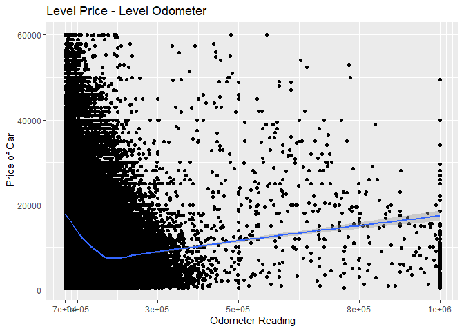

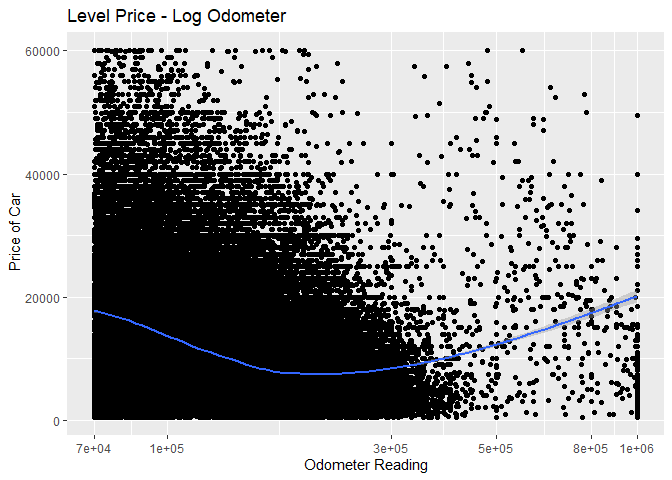

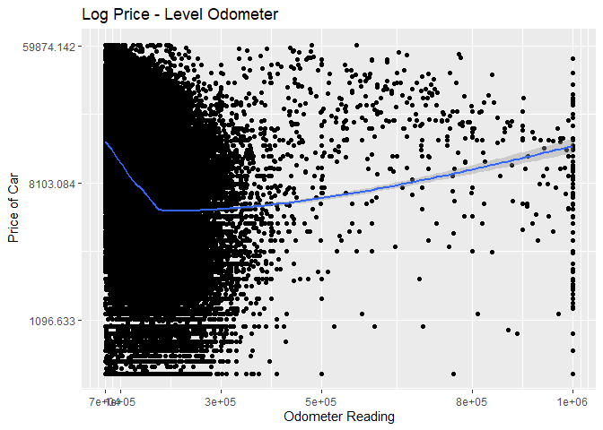

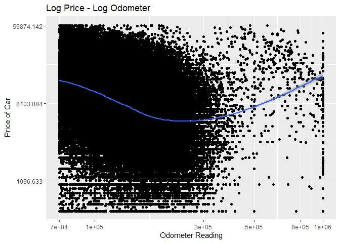

Figure 2: Exploration of model visualization: Price - Age

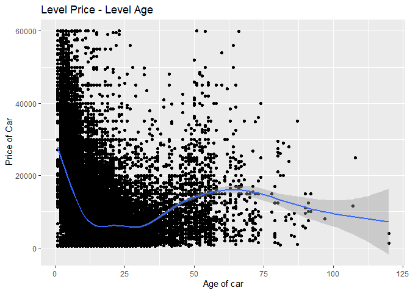

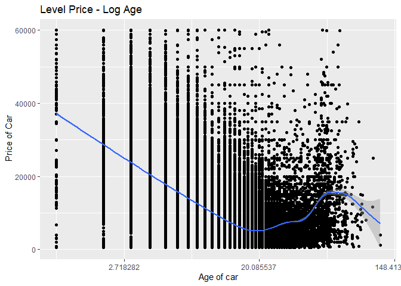

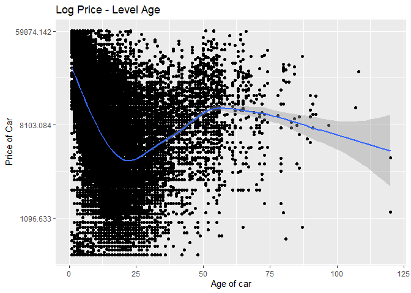

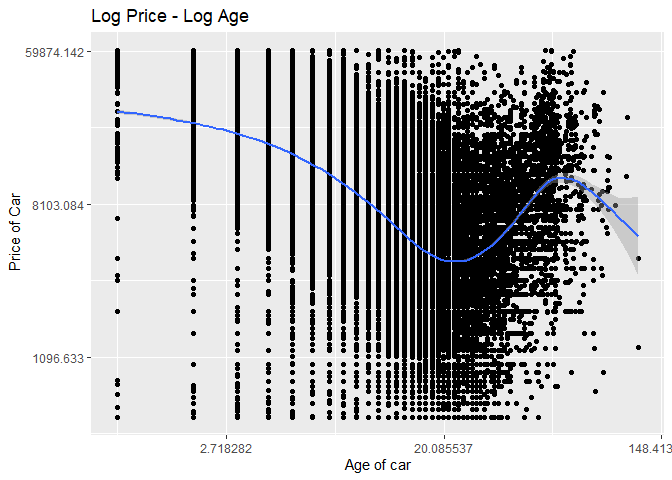

Figure 3: Regression Models:

|  | Log Price/odometer-lin | Log Price/odometer-split | Log Price/age-lin | Log Price/age-split |
| --- | --- | --- | --- | --- |
| (Intercept) | 9.62 *** | 9.99 *** | 9.66 *** | 10.03 *** |
|  | (0.01) | (0.01) | (0.01) | (0.00) |
| odometer | -0.00 *** |  |  |  |
|  | (0.00) |  |  |  |
| lspline(odometer, cutoff)1 |  | -0.00 *** |  |  |
|  |  | (0.00) |  |  |
| lspline(odometer, cutoff)2 |  | 0.00 *** |  |  |
|  |  | (0.00) |  |  |
| age |  |  | -0.06 *** |  |
|  |  |  | (0.00) |  |
| lspline(age, cutoff2)1 |  |  |  | -0.09 *** |
|  |  |  |  | (0.00) |
| lspline(age, cutoff2)2 |  |  |  | 0.06 *** |
|  |  |  |  | (0.00) |
| nobs | 223469 | 223469 | 223469 | 223469 |
| r.squared | 0.09 | 0.15 | 0.21 | 0.34 |
| adj.r.squared | 0.09 | 0.15 | 0.21 | 0.34 |
| statistic | 3406.98 | 16677.24 | 9289.51 | 40619.77 |
| p.value | 0.00 | 0.00 | 0.00 | 0.00 |
| df.residual | 223467.00 | 223466.00 | 223467.00 | 223466.00 |
| nobs.1 | 223469.00 | 223469.00 | 223469.00 | 223469.00 |
| se_type | HC2.00 | HC2.00 | HC2.00 | HC2.00 |
| *** p < 0.001; ** p < 0.01; * p < 0.05. |  |  |  |  |

|  | Ln(Price)/odometer/age-lin | Ln(Price)/odometer-W.lin | Ln(Price)/odometer-quad | Ln(Price)/age-quad |
| --- | --- | --- | --- | --- |
| (Intercept) | 9.94 *** | 9.27 *** | 10.12 *** | 10.22 *** |
|  | (0.01) | (0.02) | (0.01) | (0.01) |
| odometer | -0.00 *** | -0.00 *** | -0.00 *** |  |
|  | (0.00) | (0.00) | (0.00) |  |
| age | -0.05 *** |  |  | -0.14 *** |
|  | (0.00) |  |  | (0.00) |
| od_sq |  |  | 0.00 *** |  |
|  |  |  | (0.00) |  |
| age_sq |  |  |  | 0.00 *** |
|  |  |  |  | (0.00) |
| nobs | 223469 | 223469 | 223469 | 223469 |
| r.squared | 0.24 | 0.06 | 0.14 | 0.33 |
| adj.r.squared | 0.24 | 0.06 | 0.14 | 0.33 |
| statistic | 6321.76 | 723.04 | 13022.40 | 28780.48 |
| p.value | 0.00 | 0.00 | 0.00 | 0.00 |
| df.residual | 223466.00 | 223467.00 | 223466.00 | 223466.00 |
| nobs.1 | 223469.00 | 223469.00 | 223469.00 | 223469.00 |
| se_type | HC2.00 | HC2.00 | HC2.00 | HC2.00 |
| *** p < 0.001; ** p < 0.01; * p < 0.05. |  |  |  |  |

Figure 4: Visualization of Regression Models:

[figure not shown]

[figure not shown]

[figure not shown]

[figure not shown]

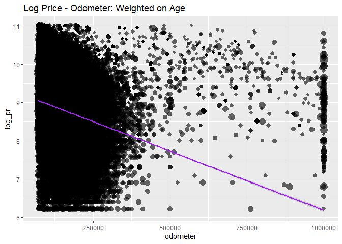

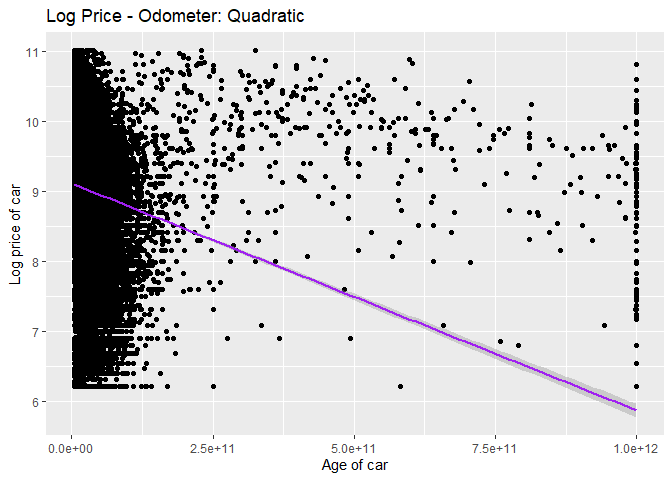

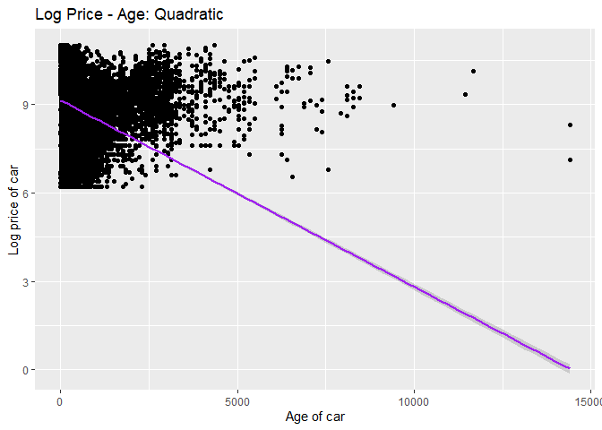

Figure 5: Robustness Check:

|  | Log Price/odometer-lin | Log Price/odometer-split | Log Price/age-lin | Log Price/age-split |
| --- | --- | --- | --- | --- |
| (Intercept) | 9.64 *** | 10.00 *** | 9.68 *** | 10.03 *** |
|  | (0.02) | (0.01) | (0.01) | (0.01) |
| odometer | -0.00 *** |  |  |  |
|  | (0.00) |  |  |  |
| lspline(odometer, cutoff)1 |  | -0.00 *** |  |  |
|  |  | (0.00) |  |  |
| lspline(odometer, cutoff)2 |  | 0.00 *** |  |  |
|  |  | (0.00) |  |  |
| age |  |  | -0.06 *** |  |
|  |  |  | (0.00) |  |
| lspline(age, cutoff2)1 |  |  |  | -0.09 *** |
|  |  |  |  | (0.00) |
| lspline(age, cutoff2)2 |  |  |  | 0.05 *** |
|  |  |  |  | (0.00) |
| nobs | 44694 | 44694 | 44694 | 44694 |
| r.squared | 0.09 | 0.15 | 0.21 | 0.34 |
| adj.r.squared | 0.09 | 0.15 | 0.21 | 0.34 |
| statistic | 717.43 | 3348.05 | 2019.70 | 8360.63 |
| p.value | 0.00 | 0.00 | 0.00 | 0.00 |
| df.residual | 44692.00 | 44691.00 | 44692.00 | 44691.00 |
| nobs.1 | 44694.00 | 44694.00 | 44694.00 | 44694.00 |
| se_type | HC2.00 | HC2.00 | HC2.00 | HC2.00 |
| *** p < 0.001; ** p < 0.01; * p < 0.05. |  |  |  |  |

|  | Ln(Price)/odometer/age-lin | Ln(Price)/odometer-W.lin | Ln(Price)/odometer-quad | Ln(Price)/age-quad |
| --- | --- | --- | --- | --- |
| (Intercept) | 9.96 *** | 9.30 *** | 10.13 *** | 10.25 *** |
|  | (0.02) | (0.03) | (0.02) | (0.02) |
| odometer | -0.00 *** | -0.00 *** | -0.00 *** |  |
|  | (0.00) | (0.00) | (0.00) |  |
| age | -0.05 *** |  |  | -0.14 *** |
|  | (0.00) |  |  | (0.00) |
| od_sq |  |  | 0.00 *** |  |
|  |  |  | (0.00) |  |
| age_sq |  |  |  | 0.00 *** |
|  |  |  |  | (0.00) |
| nobs | 44694 | 44694 | 44694 | 44694 |
| r.squared | 0.24 | 0.07 | 0.14 | 0.34 |
| adj.r.squared | 0.24 | 0.07 | 0.14 | 0.34 |
| statistic | 1438.20 | 193.06 | 2643.80 | 7430.78 |
| p.value | 0.00 | 0.00 | 0.00 | 0.00 |
| df.residual | 44691.00 | 44692.00 | 44691.00 | 44691.00 |
| nobs.1 | 44694.00 | 44694.00 | 44694.00 | 44694.00 |
| se_type | HC2.00 | HC2.00 | HC2.00 | HC2.00 |
| *** p < 0.001; ** p < 0.01; * p < 0.05. |  |  |  |  |

Figure 6: Visualization for Robustness check:

[figure not shown]

[figure not shown]

[figure not shown]

[figure not shown]

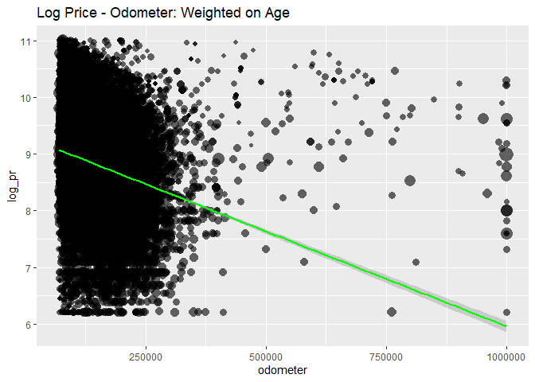

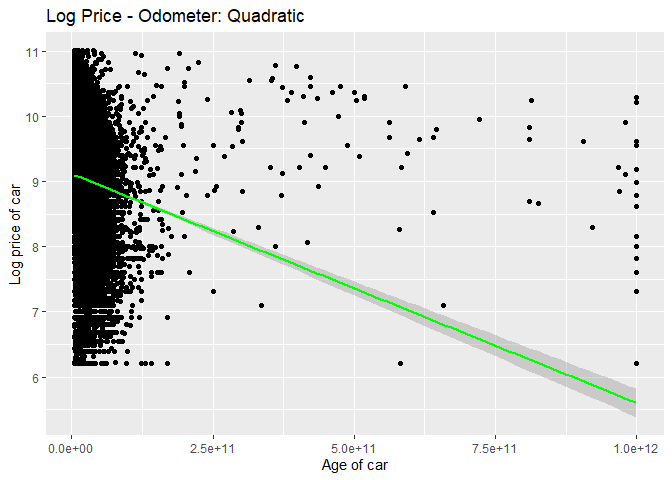

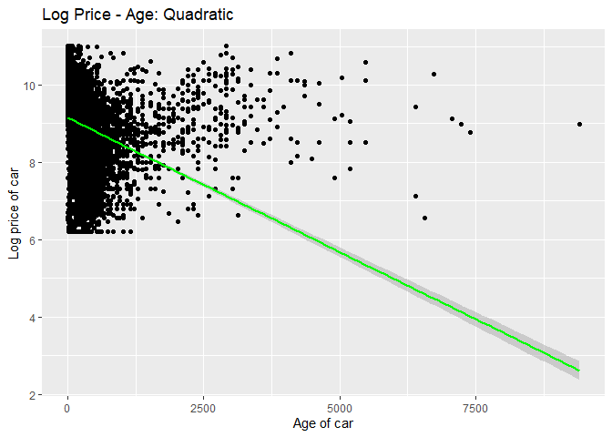

## Github repository:

[Github](https://github.com/DiamantEszter97/Coding1-DA-Assigment1/tree/master/Used_cars)